# Differential Binding Analysis

Group 1

2023-07-08

```r
suppressPackageStartupMessages({
  library(GenomicRanges)
  library(epiwraps)
  library(ggplot2)
  library(rGREAT)
  library(AnnotationHub)
  library(MotifDb)
  #library(memes)
  library(universalmotif)
  library(ensembldb)
  library(Rsamtools)
  library(motifmatchr)
  library(sechm)
  library(BiocParallel)
  library(chromVAR) # for motif accessibility estimation
  library(SummarizedExperiment) # data structure
  library(limma) # for statistical analysis
  library(bsseq)
  library(edgeR)
  library(DMRcate)
  library(rtracklayer)
  library(pheatmap)
  library(viridis)
  library(data.table)
  library(BRGenomics)
  library(BioMartGOGeneSets) # for GO analysis
  library(BSgenome.Rnorvegicus.UCSC.rn7)
})
```

```
## See system.file("LICENSE", package="MotifDb") for use restrictions.
```

# Differential binding analysis

```r
# prepare regions and tracks
tracks_1 <- list.files(path = "D:\\bioinformatics_final_project\\Laura\\Bw", pattern="GR.bw$", full = TRUE)
tracks_2 <- list.files(path = "D:\\bioinformatics_final_project\\Laura\\Bw", pattern="MR.bw$", full = TRUE)
region_files_1 <- list.files(path = "D:\\bioinformatics_final_project\\Laura\\NarrowPeaks",full=TRUE, pattern = "GR_peaks.narrowPeak")
peaks_1 <- lapply(region_files_1, FUN=rtracklayer::import)
regions_1 <- reduce(unlist(GRangesList(peaks_1)))
region_files_2 <- list.files(path = "D:\\bioinformatics_final_project\\Laura\\NarrowPeaks",full=TRUE, pattern = "MR_peaks.narrowPeak")
peaks_2 <- lapply(region_files_2, FUN=rtracklayer::import)
regions_2 <- reduce(unlist(GRangesList(peaks_2)))
# get a list of the bam files for the different samples
bams_1 <- list.files(path = "D:\\bioinformatics_final_project\\Laura\\Aligned", full=TRUE, pattern = "GR.bam$")
bams_2 <- list.files(path = "D:\\bioinformatics_final_project\\Laura\\Aligned", full=TRUE, pattern = "MR.bam$")
# create SE object
se_1 <- chromVAR::getCounts(alignment_files = bams_1, peaks = regions_1, paired = TRUE)
```

```
## Reading in file: D:\bioinformatics_final_project\Laura\Aligned/SRX5371942.GSM3602775.Late_afternoon_baseline_GR.bam
```

```
## Reading in file: D:\bioinformatics_final_project\Laura\Aligned/SRX5371944.GSM3602751.Early_morning_baseline_GR.bam
```

```
## Reading in file: D:\bioinformatics_final_project\Laura\Aligned/SRX5371947.GSM3602754.Acute_stress_GR.bam
```

```
## Reading in file: D:\bioinformatics_final_project\Laura\Aligned/SRX5371950.GSM3602757.Late_afternoon_baseline_GR.bam
```

```
## Reading in file: D:\bioinformatics_final_project\Laura\Aligned/SRX5371953.GSM3602760.Early_morning_baseline_GR.bam
```

```
## Reading in file: D:\bioinformatics_final_project\Laura\Aligned/SRX5371956.GSM3602763.Acute_stress_GR.bam
```

```
## Reading in file: D:\bioinformatics_final_project\Laura\Aligned/SRX5371959.GSM3602766.Late_afternoon_baseline_GR.bam
```

```
## Reading in file: D:\bioinformatics_final_project\Laura\Aligned/SRX5371962.GSM3602769.Early_morning_baseline_GR.bam
```

```
## Reading in file: D:\bioinformatics_final_project\Laura\Aligned/SRX5371965.GSM3602772.Acute_stress_GR.bam
```

```
## Reading in file: D:\bioinformatics_final_project\Laura\Aligned/SRX5371969.GSM3602778.Early_morning_baseline_GR.bam
```

```
## Reading in file: D:\bioinformatics_final_project\Laura\Aligned/SRX5371972.GSM3602781.Acute_stress_GR.bam
```

```
## Reading in file: D:\bioinformatics_final_project\Laura\Aligned/SRX5371975.GSM3602784.Late_afternoon_baseline_GR.bam
```

```r
colnames(se_1) <- gsub("\\.bam","",basename(bams_1))
se_1$condition <- c("BLPM", "BLAM", "FS30", "BLPM", "BLAM", "FS30", "BLPM", "BLAM", "FS30", "FS30", "BLAM", "BLPM")
se_2 <- chromVAR::getCounts(alignment_files = bams_2, peaks = regions_2, paired = TRUE)
```

```
## Reading in file: D:\bioinformatics_final_project\Laura\Aligned/SRX5371943.GSM3602776.Late_afternoon_baseline_MR.bam
```

```
## Reading in file: D:\bioinformatics_final_project\Laura\Aligned/SRX5371945.GSM3602752.Early_morning_baseline_MR.bam
```

```
## Reading in file: D:\bioinformatics_final_project\Laura\Aligned/SRX5371948.GSM3602755.Acute_stress_MR.bam
```

```
## Reading in file: D:\bioinformatics_final_project\Laura\Aligned/SRX5371951.GSM3602758.Late_afternoon_baseline_MR.bam
```

```
## Reading in file: D:\bioinformatics_final_project\Laura\Aligned/SRX5371954.GSM3602761.Early_morning_baseline_MR.bam
```

```
## Reading in file: D:\bioinformatics_final_project\Laura\Aligned/SRX5371957.GSM3602764.Acute_stress_MR.bam
```

```
## Reading in file: D:\bioinformatics_final_project\Laura\Aligned/SRX5371960.GSM3602767.Late_afternoon_baseline_MR.bam
```

```
## Reading in file: D:\bioinformatics_final_project\Laura\Aligned/SRX5371963.GSM3602770.Early_morning_baseline_MR.bam
```

```
## Reading in file: D:\bioinformatics_final_project\Laura\Aligned/SRX5371966.GSM3602773.Acute_stress_MR.bam
```

```
## Reading in file: D:\bioinformatics_final_project\Laura\Aligned/SRX5371970.GSM3602779.Early_morning_baseline_MR.bam
```

```
## Reading in file: D:\bioinformatics_final_project\Laura\Aligned/SRX5371973.GSM3602782.Acute_stress_MR.bam
```

```
## Reading in file: D:\bioinformatics_final_project\Laura\Aligned/SRX5371976.GSM3602785.Late_afternoon_baseline_MR.bam
```

```r
colnames(se_2) <- gsub("\\.bam","",basename(bams_2))
se_2$condition <- c("BLPM", "BLAM", "FS30", "BLPM", "BLAM", "FS30", "BLPM", "BLAM", "FS30", "FS30", "BLAM", "BLPM")
# Differential binding analysis
row.names(se_1) <- as.character(granges(se_1)) #give names to the regions
dds_1 <- DGEList(assay(se_1), group=se_1$condition) #gene expression list
dds_1 <- calcNormFactors(dds_1) #normalization factor
dds_1 <- estimateDisp(dds_1)
```

```
## Using classic mode.
```

```r
et_1 <- as.data.frame(topTags(exactTest(dds_1), Inf))
head(et_1) # logCPM = log counts per million
```

```
##                           logFC   logCPM       PValue        FDR
## 10:93164404-93164681   1.578157 4.388943 2.266133e-06 0.01862761
## 4:68135549-68136119   -1.668552 3.860289 1.301680e-04 0.45869448
## 2:242488883-242489210  1.060500 4.735656 1.674067e-04 0.45869448
## 10:35416703-35417135   1.761941 4.546935 2.665658e-04 0.49570029
## 17:69236787-69237180   1.488998 4.363618 3.572332e-04 0.49570029
## 12:24308578-24308957   1.407118 4.639266 3.717657e-04 0.49570029
```

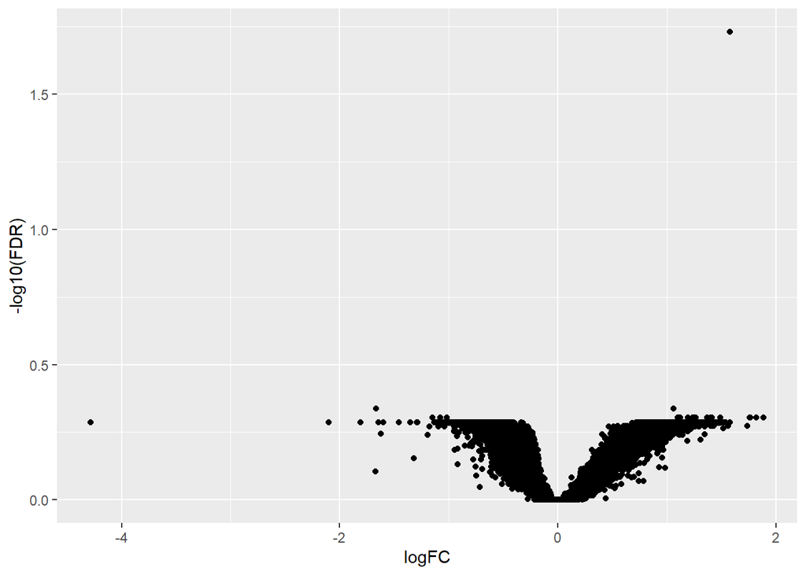

```r
ggplot(et_1, aes(logFC, -log10(FDR))) + geom_point()
```

```r
row.names(se_2) <- as.character(granges(se_2)) #give names to the regions
dds_2 <- DGEList(assay(se_2), group=se_2$condition) #gene expression list
dds_2 <- calcNormFactors(dds_2) #normalization factor
dds_2 <- estimateDisp(dds_2)
```

```
## Using classic mode.
```

```r
et_2 <- as.data.frame(topTags(exactTest(dds_2), Inf))
head(et_2) # logCPM = log counts per million
```

```
##                          logFC   logCPM       PValue         FDR
## 11:82915490-82916118  1.438650 6.804467 1.583043e-07 0.001660454
## 3:154627487-154627967 1.275668 5.868949 7.617583e-07 0.002721307
## 17:71678929-71679269  1.493422 4.753083 1.166298e-06 0.002721307
## 14:91224684-91225036  1.566823 4.400949 1.545027e-06 0.002721307
## 1:245793286-245793928 1.370533 6.109180 1.560283e-06 0.002721307
## 20:6581071-6581853    1.247660 8.002784 1.748134e-06 0.002721307
```

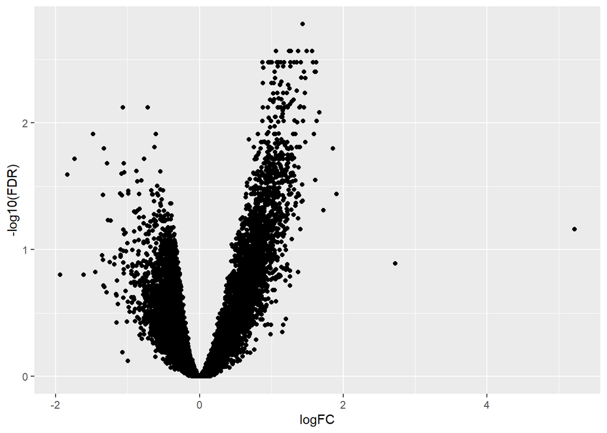

```r
ggplot(et_2, aes(logFC, -log10(FDR))) + geom_point()
```

```r
# Try different normalization
# GR
# set normalization factor to 1
dds_1$samples$norm.factors <- 1
dds_1 <- estimateDisp(dds_1)
```

```
## Using classic mode.
```

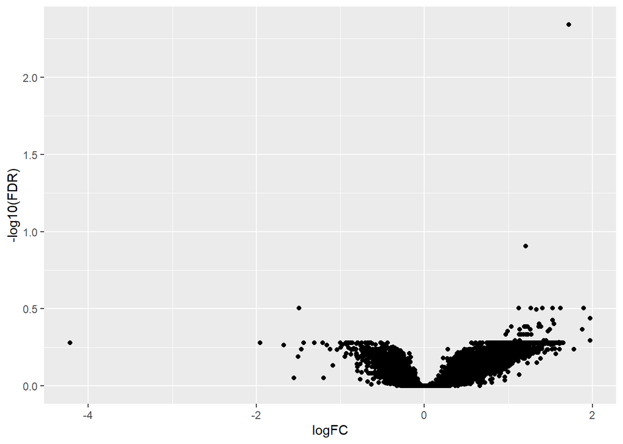

```r
et_1 <- as.data.frame(topTags(exactTest(dds_1), Inf))
ggplot(et_1, aes(logFC, -log10(FDR))) + geom_point()
```

```r
# Normalization based on common peaks
nf.ma <- epiwraps:::getNormFactors(bams_1, peaks=peaks_1, method="MAnorm")
```

```
## `paired` unspecified, assuming the data to be single-end...
```

```
## Comparing coverage in peaks...
```

```r
dds_1$samples$norm.factors <- nf.ma
dds_1$samples$lib.size <- 1
dds_1 <- estimateDisp(dds_1) # run analysis again
```

```
## Using classic mode.
```

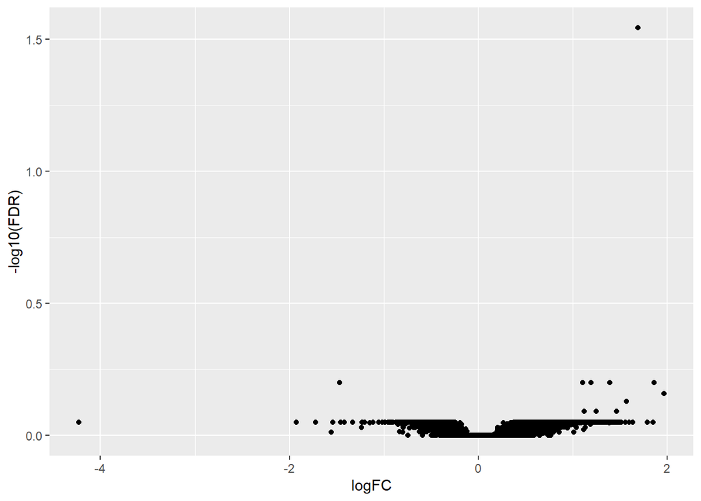

```r
et_1 <- as.data.frame(topTags(exactTest(dds_1), Inf))
ggplot(et_1, aes(logFC, -log10(FDR))) + geom_point()
```

```r
# Background normalization
nf.bg <- epiwraps:::getNormFactors(bams_1, method="background")
```

```
## `paired` unspecified, assuming the data to be single-end...
```

```
## Comparing coverage in random regions...
```

```r
dds_1$samples$norm.factors <- nf.bg
dds_1$samples$lib.size <- 1
dds_1 <- estimateDisp(dds_1)
```

```
## Using classic mode.
```

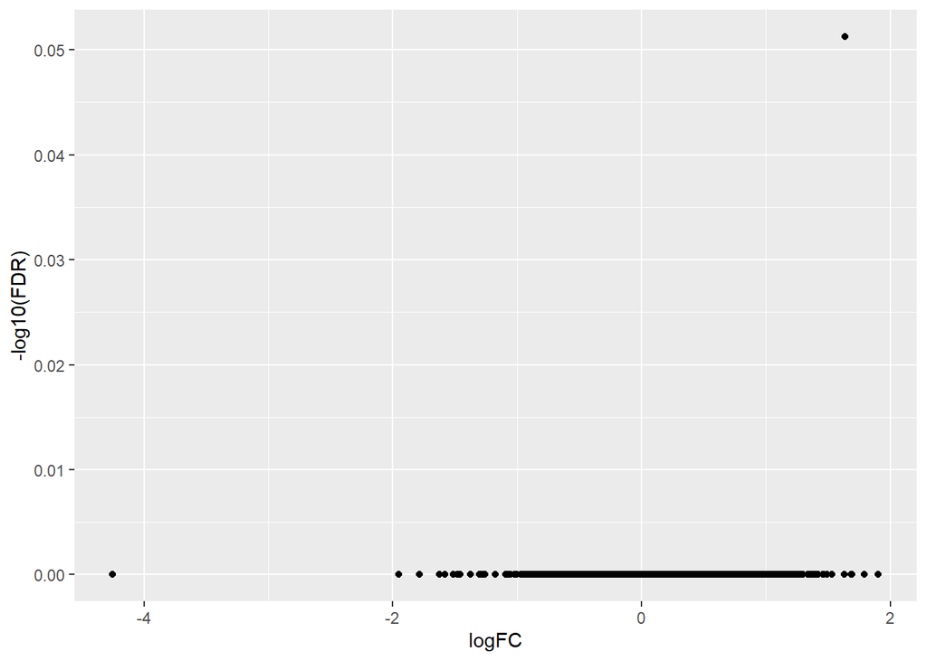

```r
et_1 <- as.data.frame(topTags(exactTest(dds_1), Inf))
ggplot(et_1, aes(logFC, -log10(FDR))) + geom_point()
```

```r
# MR
# set normalization factor to 1
dds_2$samples$norm.factors <- 1
dds_2 <- estimateDisp(dds_2)
```

```
## Using classic mode.
```

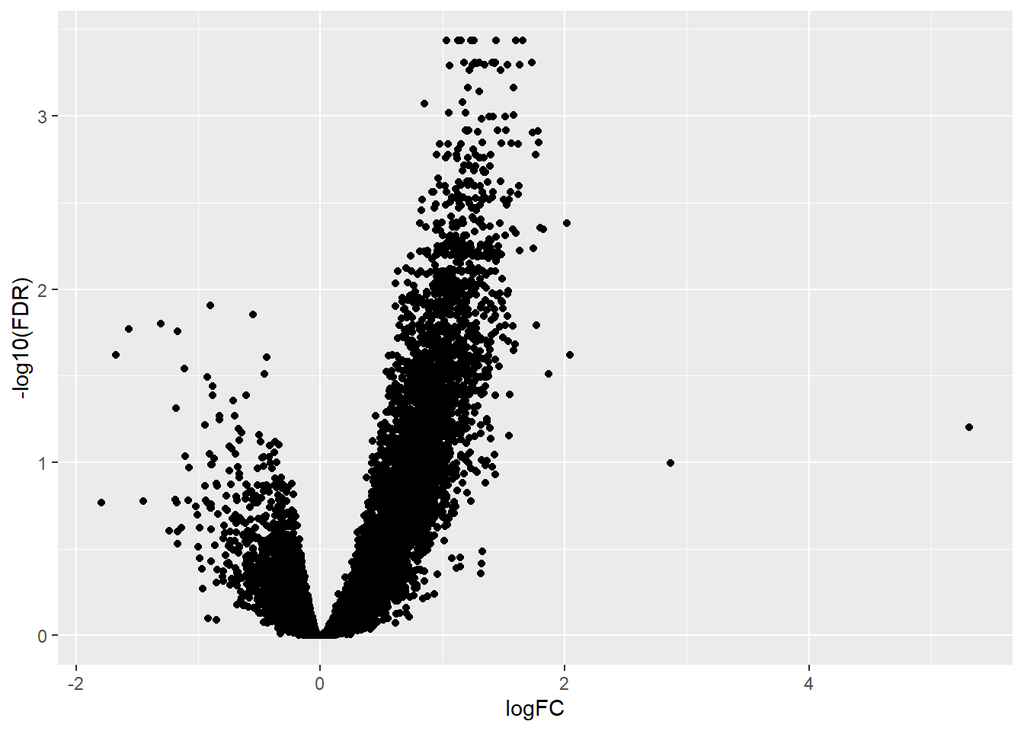

```r
et_2 <- as.data.frame(topTags(exactTest(dds_2), Inf))
ggplot(et_2, aes(logFC, -log10(FDR))) + geom_point()
```

```r
# Normalization based on common peaks
nf.ma <- epiwraps:::getNormFactors(bams_2, peaks=peaks_2, method="MAnorm")
```

```
## `paired` unspecified, assuming the data to be single-end...
```

```
## Comparing coverage in peaks...
```

```r
dds_2$samples$norm.factors <- nf.ma
dds_2$samples$lib.size <- 1
dds_2 <- estimateDisp(dds_2) # run analysis again
```

```
## Using classic mode.
```

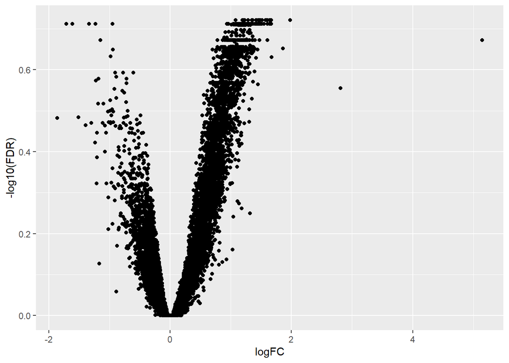

```r
et_2 <- as.data.frame(topTags(exactTest(dds_2), Inf))
ggplot(et_2, aes(logFC, -log10(FDR))) + geom_point()
```

```r
# Background normalization
nf.bg <- epiwraps:::getNormFactors(bams_2, method="background")
```

```
## `paired` unspecified, assuming the data to be single-end...
```

```
## Comparing coverage in random regions...
```

```r
dds_2$samples$norm.factors <- nf.bg
dds_2$samples$lib.size <- 1
dds_2 <- estimateDisp(dds_2)
```

```
## Using classic mode.
```

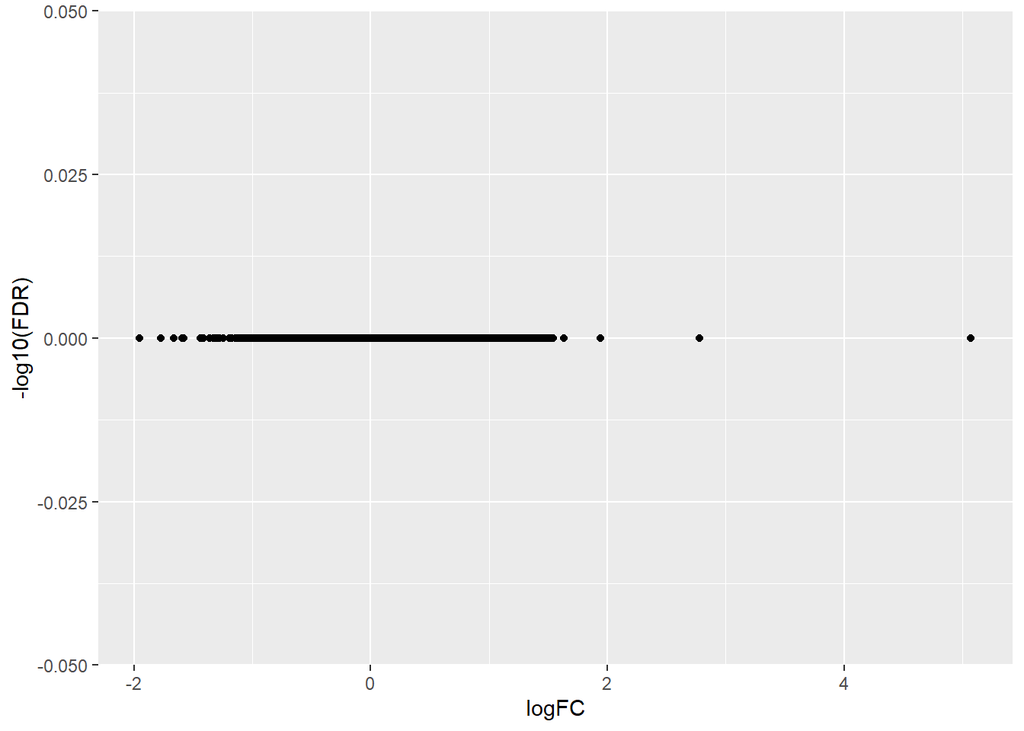

```r
et_2 <- as.data.frame(topTags(exactTest(dds_2), Inf))
ggplot(et_2, aes(logFC, -log10(FDR))) + geom_point()
```

```r
# Top differentially bound peaks
sm_1 <- signal2Matrix(tracks_1, rowRanges(se_1))
```

```
## Reading D:\bioinformatics_final_project\Laura\Bw/SRX5371942.GSM3602775.Late_afternoon_baseline_GR.bw
```

```
## Reading D:\bioinformatics_final_project\Laura\Bw/SRX5371944.GSM3602751.Early_morning_baseline_GR.bw
```

```
## Reading D:\bioinformatics_final_project\Laura\Bw/SRX5371947.GSM3602754.Acute_stress_GR.bw
```

```
## Reading D:\bioinformatics_final_project\Laura\Bw/SRX5371950.GSM3602757.Late_afternoon_baseline_GR.bw
```

```
## Reading D:\bioinformatics_final_project\Laura\Bw/SRX5371953.GSM3602760.Early_morning_baseline_GR.bw
```

```
## Reading D:\bioinformatics_final_project\Laura\Bw/SRX5371956.GSM3602763.Acute_stress_GR.bw
```

```
## Reading D:\bioinformatics_final_project\Laura\Bw/SRX5371959.GSM3602766.Late_afternoon_baseline_GR.bw
```

```
## Reading D:\bioinformatics_final_project\Laura\Bw/SRX5371962.GSM3602769.Early_morning_baseline_GR.bw
```

```
## Reading D:\bioinformatics_final_project\Laura\Bw/SRX5371965.GSM3602772.Acute_stress_GR.bw
```

```
## Reading D:\bioinformatics_final_project\Laura\Bw/SRX5371969.GSM3602778.Early_morning_baseline_GR.bw
```

```
## Reading D:\bioinformatics_final_project\Laura\Bw/SRX5371972.GSM3602781.Acute_stress_GR.bw
```

```
## Reading D:\bioinformatics_final_project\Laura\Bw/SRX5371975.GSM3602784.Late_afternoon_baseline_GR.bw
```

```
## 'magick' package is suggested to install to give better rasterization.
##
## Set `ht_opt$message = FALSE` to turn off this message.
```

```
## 'magick' package is suggested to install to give better rasterization.
##
## Set `ht_opt$message = FALSE` to turn off this message.
## 'magick' package is suggested to install to give better rasterization.
##
## Set `ht_opt$message = FALSE` to turn off this message.
```

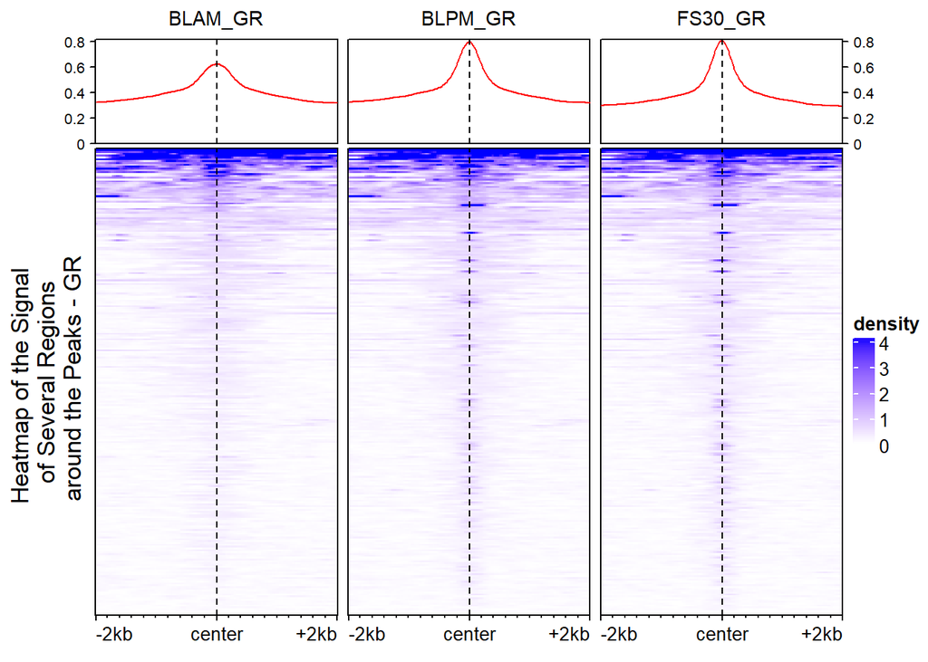

```r
#nf_1 <- getNormFactors(tracks_1, peaks=peaks_1)
nf_1 <- rep(1, length(sm_1)) # normalization to 1 looked better (see before)
smn_1 <- rescaleSignalMatrices(sm_1, nf_1)
names(smn_1) <- c("GR_peaks_BLPM_A", "GR_peaks_BLAM_A", "GR_peaks_FS30_A", "GR_peaks_BLPM_B", "GR_peaks_BLAM_B", "GR_peaks_FS30_B", "GR_peaks_BLPM_C", "GR_peaks_BLAM_C", "GR_peaks_FS30_C", "GR_peaks_BLAM_D", "GR_peaks_FS30_D", "GR_peaks_BLPM_D")
smMerged_1 <- list(
  BLAM_GR = mergeSignalMatrices(smn_1[c("GR_peaks_BLAM_A","GR_peaks_BLAM_B", "GR_peaks_BLAM_C", "GR_peaks_BLAM_D")]),
  BLPM_GR = mergeSignalMatrices(smn_1[c("GR_peaks_BLPM_A","GR_peaks_BLPM_B", "GR_peaks_BLPM_C", "GR_peaks_BLPM_D")]),
  FS30_GR = mergeSignalMatrices(smn_1[c("GR_peaks_FS30_A","GR_peaks_FS30_B", "GR_peaks_FS30_C", "GR_peaks_FS30_D")]))
plotEnrichedHeatmaps(smMerged_1,colors = c("white", "blue"), row_title = "Heatmap of the Signal \n of Several Regions \n around the Peaks - GR")
```

```r
sm_1 <- signal2Matrix(tracks_1, as(head(row.names(et_1),20),"GRanges"))
```

```
## Reading D:\bioinformatics_final_project\Laura\Bw/SRX5371942.GSM3602775.Late_afternoon_baseline_GR.bw
```

```
## Reading D:\bioinformatics_final_project\Laura\Bw/SRX5371944.GSM3602751.Early_morning_baseline_GR.bw
```

```
## Reading D:\bioinformatics_final_project\Laura\Bw/SRX5371947.GSM3602754.Acute_stress_GR.bw
```

```
## Reading D:\bioinformatics_final_project\Laura\Bw/SRX5371950.GSM3602757.Late_afternoon_baseline_GR.bw
```

```
## Reading D:\bioinformatics_final_project\Laura\Bw/SRX5371953.GSM3602760.Early_morning_baseline_GR.bw
```

```
## Reading D:\bioinformatics_final_project\Laura\Bw/SRX5371956.GSM3602763.Acute_stress_GR.bw
```

```
## Reading D:\bioinformatics_final_project\Laura\Bw/SRX5371959.GSM3602766.Late_afternoon_baseline_GR.bw
```

```
## Reading D:\bioinformatics_final_project\Laura\Bw/SRX5371962.GSM3602769.Early_morning_baseline_GR.bw
```

```
## Reading D:\bioinformatics_final_project\Laura\Bw/SRX5371965.GSM3602772.Acute_stress_GR.bw
```

```
## Reading D:\bioinformatics_final_project\Laura\Bw/SRX5371969.GSM3602778.Early_morning_baseline_GR.bw
```

```
## Reading D:\bioinformatics_final_project\Laura\Bw/SRX5371972.GSM3602781.Acute_stress_GR.bw
```

```
## Reading D:\bioinformatics_final_project\Laura\Bw/SRX5371975.GSM3602784.Late_afternoon_baseline_GR.bw
```

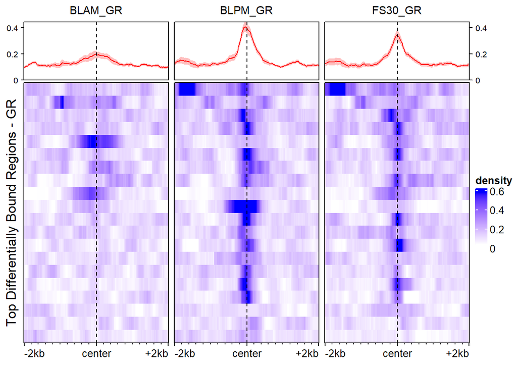

```r
smn_1 <- rescaleSignalMatrices(sm_1, nf_1)
names(smn_1) <- c("GR_peaks_BLPM_A", "GR_peaks_BLAM_A", "GR_peaks_FS30_A", "GR_peaks_BLPM_B", "GR_peaks_BLAM_B", "GR_peaks_FS30_B", "GR_peaks_BLPM_C", "GR_peaks_BLAM_C", "GR_peaks_FS30_C", "GR_peaks_BLAM_D", "GR_peaks_FS30_D", "GR_peaks_BLPM_D")
smMerged_1 <- list(
  BLAM_GR = mergeSignalMatrices(smn_1[c("GR_peaks_BLAM_A","GR_peaks_BLAM_B", "GR_peaks_BLAM_C", "GR_peaks_BLAM_D")]),
  BLPM_GR = mergeSignalMatrices(smn_1[c("GR_peaks_BLPM_A","GR_peaks_BLPM_B", "GR_peaks_BLPM_C", "GR_peaks_BLPM_D")]),
  FS30_GR = mergeSignalMatrices(smn_1[c("GR_peaks_FS30_A","GR_peaks_FS30_B", "GR_peaks_FS30_C", "GR_peaks_FS30_D")]))
plotEnrichedHeatmaps(smMerged_1,colors = c("white", "blue"), row_title = "Top Differentially Bound Regions - GR")
```

```r
sm_2 <- signal2Matrix(tracks_2, rowRanges(se_2))
```

```
## Reading D:\bioinformatics_final_project\Laura\Bw/SRX5371943.GSM3602776.Late_afternoon_baseline_MR.bw
```

```
## Reading D:\bioinformatics_final_project\Laura\Bw/SRX5371945.GSM3602752.Early_morning_baseline_MR.bw
```

```
## Reading D:\bioinformatics_final_project\Laura\Bw/SRX5371948.GSM3602755.Acute_stress_MR.bw
```

```
## Reading D:\bioinformatics_final_project\Laura\Bw/SRX5371951.GSM3602758.Late_afternoon_baseline_MR.bw
```

```
## Reading D:\bioinformatics_final_project\Laura\Bw/SRX5371954.GSM3602761.Early_morning_baseline_MR.bw
```

```
## Reading D:\bioinformatics_final_project\Laura\Bw/SRX5371957.GSM3602764.Acute_stress_MR.bw
```

```
## Reading D:\bioinformatics_final_project\Laura\Bw/SRX5371960.GSM3602767.Late_afternoon_baseline_MR.bw
```

```
## Reading D:\bioinformatics_final_project\Laura\Bw/SRX5371963.GSM3602770.Early_morning_baseline_MR.bw
```

```
## Reading D:\bioinformatics_final_project\Laura\Bw/SRX5371966.GSM3602773.Acute_stress_MR.bw
```

```
## Reading D:\bioinformatics_final_project\Laura\Bw/SRX5371970.GSM3602779.Early_morning_baseline_MR.bw
```

```
## Reading D:\bioinformatics_final_project\Laura\Bw/SRX5371973.GSM3602782.Acute_stress_MR.bw
```

```
## Reading D:\bioinformatics_final_project\Laura\Bw/SRX5371976.GSM3602785.Late_afternoon_baseline_MR.bw
```

```
## 'magick' package is suggested to install to give better rasterization.
##
## Set `ht_opt$message = FALSE` to turn off this message.
```

```
## 'magick' package is suggested to install to give better rasterization.
##
## Set `ht_opt$message = FALSE` to turn off this message.
## 'magick' package is suggested to install to give better rasterization.
##
## Set `ht_opt$message = FALSE` to turn off this message.
```

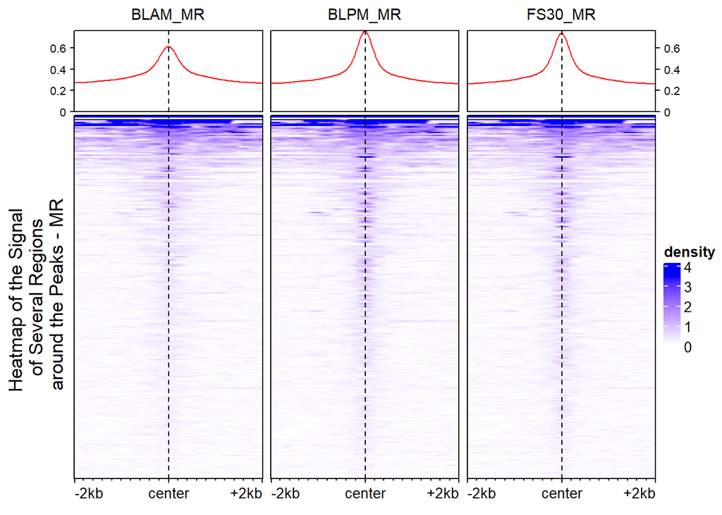

```r
#nf_2 <- getNormFactors(tracks_2, peaks=peaks_2)
nf_2 <- rep(1, length(sm_2)) # normalization to 1 looked better (see before)
smn_2 <- rescaleSignalMatrices(sm_2, nf_2)
names(smn_2) <- c("MR_peaks_BLPM_A", "MR_peaks_BLAM_A", "MR_peaks_FS30_A", "MR_peaks_BLPM_B", "MR_peaks_BLAM_B", "MR_peaks_FS30_B", "MR_peaks_BLPM_C", "MR_peaks_BLAM_C", "MR_peaks_FS30_C", "MR_peaks_BLAM_D", "MR_peaks_FS30_D", "MR_peaks_BLPM_D")
smMerged_2 <- list(
  BLAM_MR = mergeSignalMatrices(smn_2[c("MR_peaks_BLAM_A","MR_peaks_BLAM_B", "MR_peaks_BLAM_C", "MR_peaks_BLAM_D")]),
  BLPM_MR = mergeSignalMatrices(smn_2[c("MR_peaks_BLPM_A","MR_peaks_BLPM_B", "MR_peaks_BLPM_C", "MR_peaks_BLPM_D")]),
  FS30_MR = mergeSignalMatrices(smn_2[c("MR_peaks_FS30_A","MR_peaks_FS30_B", "MR_peaks_FS30_C", "MR_peaks_FS30_D")]))
plotEnrichedHeatmaps(smMerged_2,colors = c("white", "blue"), row_title = "Heatmap of the Signal \n of Several Regions \n around the Peaks - MR")
```

```r
sm_2 <- signal2Matrix(tracks_2, as(head(row.names(et_2),20),"GRanges"))
```

```
## Reading D:\bioinformatics_final_project\Laura\Bw/SRX5371943.GSM3602776.Late_afternoon_baseline_MR.bw
```

```
## Reading D:\bioinformatics_final_project\Laura\Bw/SRX5371945.GSM3602752.Early_morning_baseline_MR.bw
```

```
## Reading D:\bioinformatics_final_project\Laura\Bw/SRX5371948.GSM3602755.Acute_stress_MR.bw
```

```
## Reading D:\bioinformatics_final_project\Laura\Bw/SRX5371951.GSM3602758.Late_afternoon_baseline_MR.bw
```

```
## Reading D:\bioinformatics_final_project\Laura\Bw/SRX5371954.GSM3602761.Early_morning_baseline_MR.bw
```

```
## Reading D:\bioinformatics_final_project\Laura\Bw/SRX5371957.GSM3602764.Acute_stress_MR.bw
```

```
## Reading D:\bioinformatics_final_project\Laura\Bw/SRX5371960.GSM3602767.Late_afternoon_baseline_MR.bw
```

```
## Reading D:\bioinformatics_final_project\Laura\Bw/SRX5371963.GSM3602770.Early_morning_baseline_MR.bw
```

```
## Reading D:\bioinformatics_final_project\Laura\Bw/SRX5371966.GSM3602773.Acute_stress_MR.bw
```

```
## Reading D:\bioinformatics_final_project\Laura\Bw/SRX5371970.GSM3602779.Early_morning_baseline_MR.bw
```

```
## Reading D:\bioinformatics_final_project\Laura\Bw/SRX5371973.GSM3602782.Acute_stress_MR.bw
```

```
## Reading D:\bioinformatics_final_project\Laura\Bw/SRX5371976.GSM3602785.Late_afternoon_baseline_MR.bw
```

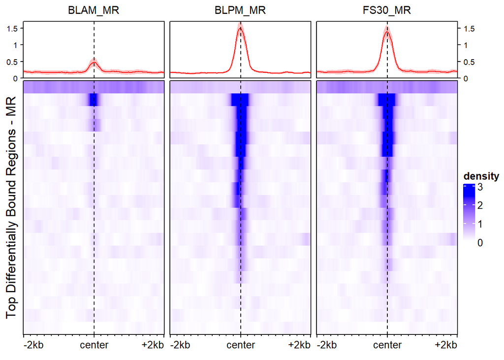

```r
smn_2 <- rescaleSignalMatrices(sm_2, nf_2)
names(smn_2) <- c("MR_peaks_BLPM_A", "MR_peaks_BLAM_A", "MR_peaks_FS30_A", "MR_peaks_BLPM_B", "MR_peaks_BLAM_B", "MR_peaks_FS30_B", "MR_peaks_BLPM_C", "MR_peaks_BLAM_C", "MR_peaks_FS30_C", "MR_peaks_BLAM_D", "MR_peaks_FS30_D", "MR_peaks_BLPM_D")
smMerged_2 <- list(
  BLAM_MR = mergeSignalMatrices(smn_2[c("MR_peaks_BLAM_A","MR_peaks_BLAM_B", "MR_peaks_BLAM_C", "MR_peaks_BLAM_D")]),
  BLPM_MR = mergeSignalMatrices(smn_2[c("MR_peaks_BLPM_A","MR_peaks_BLPM_B", "MR_peaks_BLPM_C", "MR_peaks_BLPM_D")]),
  FS30_MR = mergeSignalMatrices(smn_2[c("MR_peaks_FS30_A","MR_peaks_FS30_B", "MR_peaks_FS30_C", "MR_peaks_FS30_D")]))
plotEnrichedHeatmaps(smMerged_2,colors = c("white", "blue"), row_title = "Top Differentially Bound Regions - MR")
```

In order to see the effect of the different condition to the binding of the TF, we performed a differential binding analysis. In order to determine the best mormalization method, we compared TMM normalization, normalization to 1, MAnorm normalization, and background normalization. Based on our plots, we chose the normalization to 1, but it is still not optimal. Indeed, with increasing number of proteins we would expect a larger number of binding.

Subsequently, we produced some heatmaps showing the top differentially-bound peaks. We can clearly see that in the FS30 condition and in the BLPM condition there is more signal, confirming again the previously explained findings (clustering). In addition, we can distinguish regions where there is more binding in specific conditions, e.g. BLPM, compared to the other ones.

# Conclusion

Our analysis revealed clear differences between the stress condition and the baseline condition and also showed clear circadian effects by comparing the baseline condition measured early in the morning and the baseline condition measured late in the afternoon. Our results confirm previous findings explained in the literature, as explained previously in our analysis: Stress leads to a high glucocorticoid release, and this also happens late in the afternoon, just before the rat, being a nocturnal animal, starts its active phase.

By utilizing Upset Plots instead of Venn Diagrams, we revealed interindividual differences in stress response. The variability in response between animals is known and is thought to be partially explained by epigenetic mechanisms triggered by stressful early-life events (Ebner & Singewald, 2017).

When observing the upset Plots about half of the peaks result unique for the FS30 or BLPM condition, however when plotting these “unique” peaks on a heatmap, they are indeed not unique. This is a weakness of the original paper, where the initial part of the analysis relies heavily on overlap analysis. Caution is advised in making conclusions only based on overlapping, as there are two factors that can influence the number of overlaps that are found with the function. For one, depending on the order that the regions and tracks are fed into the function, different numbers of overlaps are found (Germain & Sonder, 2023). Additionally, the overlaps method is highly dependent on the thresholds that are set to determine whether an overlap is being counted as significant. Depending on where the thresholds are set, a different number of overlaps is the result (Brandes & Linial, 2016). Both aforementioned factors contribute to a variability in number of overlaps that can be observed.

The clustering approach helped emphasize similar signals and thus aided in depicting smaller differences between conditions, that would not be visible without clustering. This is especially helpful when comparing and distinguishing the MR and GR, as they have some overlapping functions.

The GO analysis did not yield any surprising results and, even with clustering, was very similar to the results of the paper. Still, the clustering results in more GO-plots, meaning more (cluster-specific) functions can be obtained.

The differential binding analysis did also not produce any unusual or unexpected results: Increased binding could be observed with a larger amount of proteins and increased receptor activity.

All in all, our recreation of the data was consistent with the analyses from the paper and did not yield any big surprises. Still, the clustering approach proved to be a better way of analyzing the data compared to simple overlapping, for the aforementioned reasons. The decision on what technique should be used is dependent on the individual goals and focus on detail.

# Bibliography

Briones, B. A., & Gould, E. (2019). Adult Neurogenesis and Stress. In Stress: Physiology, Biochemistry, and Pathology (pp. 79–92). Elsevier. [https://doi.org/10.1016/j.yhbeh.2008.10.015](https://doi.org/10.1016/B978-0-12-813146-6.00007-2)

Cuesta, M., Clesse, D., Pévet, P., & Challet, E. (2009). From daily behavior to hormonal and neurotransmitters rhythms: Comparison between diurnal and nocturnal rat species. Hormones and Behavior, 55(2), 338–347. https://doi.org/10.1016/j.yhbeh.2008.10.015

Dickmeis, T. (2009). Glucocorticoids and the circadian clock. Journal of Endocrinology, 200(1), 3–22. https://doi.org/10.1677/JOE-08-0415

Ebner, K., & Singewald, N. (2017). Individual differences in stress susceptibility and stress inhibitory mechanisms. Current Opinion in Behavioral Sciences, 14, 54–64. https://doi.org/10.1016/j.cobeha.2016.11.016

Gu, Z., & Hübschmann, D. (2023). rGREAT: an R/bioconductor package for functional enrichment on genomic regions. Bioinformatics, 39(1). https://doi.org/10.1093/bioinformatics/btac745

Jin, X., Zhou, M., Chen, S., Li, D., Cao, X., & Liu, B. (2022). Effects of pH alterations on stress- and aging-induced protein phase separation. Cellular and Molecular Life Sciences : CMLS, 79(7), 380. https://doi.org/10.1007/s00018-022-04393-0

Koning, A.-S. C. A. M., Buurstede, J. C., van Weert, L. T. C. M., & Meijer, O. C. (2019). Glucocorticoid and Mineralocorticoid Receptors in the Brain: A Transcriptional Perspective. Journal of the Endocrine Society, 3(10), 1917–1930. https://doi.org/10.1210/js.2019-00158

Kuti, D., Winkler, Z., Horváth, K., Juhász, B., Szilvásy-Szabó, A., Fekete, C., Ferenczi, S., & Kovács, K. J. (2022). The metabolic stress response: Adaptation to acute-, repeated- and chronic challenges in mice. IScience, 25(8), 104693. https://doi.org/10.1016/j.isci.2022.104693

Lippman, J., & Dunaevsky, A. (2005). Dendritic spine morphogenesis and plasticity. Journal of Neurobiology, 64(1), 47–57. https://doi.org/10.1002/neu.20149

Mifsud, K. R., Kennedy, C. L. M., Salatino, S., Sharma, E., Price, E. M., Haque, S. N., Gialeli, A., Goss, H. M., Panchenko, P. E., Broxholme, J., Engledow, S., Lockstone, H., Cordero Llana, O., & Reul, J. M. H. M. (2021). Distinct regulation of hippocampal neuroplasticity and ciliary genes by corticosteroid receptors. Nature Communications 2021 12:1, 12(1), 1–23. https://doi.org/10.1038/s41467-021-24967-z

Team BC, & Maintainer BP. (2019). TxDb.Rnorvegicus.UCSC.rn6.refGene: Annotation package for TxDb object(s). In R package version 3.4.6. https://bioconductor.org/packages/release/data/annotation/html/TxDb.Rnorvegicus.UCSC.rn6.refGene.html

Trollope, A., Mifsud, K., Saunderson, E., & Reul, J. (2017). Molecular and Epigenetic Mechanisms Underlying Cognitive and Adaptive Responses to Stress. Epigenomes, 1(3), 17. https://doi.org/10.3390/epigenomes1030017

Whirledge, S., & Cidlowski, J. A. (2010). Glucocorticoids, stress, and fertility. Minerva Endocrinologica, 35(2), 109–125.